# hw2

ACTIVITY 4

1. Missing completely at random (MCAR): If the probability of being missing is the same for all cases, then the data are said to be missing completely at random (MCAR). This effectively implies that causes of the missing data are unrelated to the data. The fact that the data are missing is independent of the observed and unobserved data. In other words, no systematic differences exist between rows with missing data and those with complete data. Therefore, MCAR refers to a situation where the missingness of data is entirely random and unrelated to any observed or unobserved variables in the dataset. In other words, the missing data points are missing by pure chance, and there is no systematic pattern or reason behind their absence. An example of MCAR might be a survey where respondents spill coffee on their questionnaire, causing some responses to be illegible. The coffee spill is unrelated to any characteristics of the respondents or the questions they answered.It’s purely a random occurrence.

Missing at random (MAR): If the probability of being missing is the same only within groups defined by the observed data, then the data are missing at random (MAR). There might be systematic differences between the missing and observed values, but these can be entirely explained by other observed variables. In simpler terms, the missingness is related to other observed data, making it potentially predictable, but it’s not directly influenced by the missing values. MAR occurs when the probability of missing data depends on observed variables but not on the missing values themselves. MAR is a much broader class than MCAR. An example of MAR could be a medical study where patients’ weights are missing for some follow-up visits. The likelihood of missing weight data may depend on factors like the patient’s age and overall health, but it’s not influenced by their actual weight at that visit. So, missing weight data is related to other patient characteristics, but not to their weight itself.

Missing not at random (MNAR): MNAR is the most complex and problematic type of missing data. It occurs when the probability of missing data is related to the values that are missing themselves. In MNAR, the missingness is directly associated with unobserved, often unmeasurable, attributes that are missing. This makes imputation more challenging because the missing values are inherently informative.An example of MNAR in public opinion research occurs if those with weaker opinions respond less often. MNAR is the most complex case. Strategies to handle MNAR are to find more data about the causes for the missingness, or to perform what-if analyses to see how sensitive the results are under various scenarios. Another example of MNAR might be a study on income where participants are asked about their income but refuse toanswer due to financial privacy concerns. Here, the act of not reporting income is directly linked to their income level, which is unobserved and, therefore, missing. In this case, the missing income values are informative, but they are not recorded.

2. Dropping entire rows containing at least a single missing datum without negatively biasing the dataset is typically acceptable when dealing with data that falls into the category of Missing Completely at Random (MCAR).

In MCAR, the missingness is entirely random and unrelated to any observed or unobserved variables in the dataset. This means that the missing values occur purely by chance, and there is no systematic pattern or reason behind their absence. When data is MCAR, the probability of any particular observation being missing is the same for all observations, regardless of their characteristics or the values of other variables. Importantly, MCAR implies that there is no underlying structure or mechanism that links the missing data to specific characteristics or values within the dataset. Given these characteristics of MCAR, it is reasonable to drop rows with missing data without negatively biasing the dataset.

```r
set.seed(123)

# Generate a dataset with 20 people
n <- 20

# Generate random ages between 20 and 60
ages <- sample(20:60, n, replace = TRUE)

# Create a vector of study levels
study_levels <- sample(c("High School", "Bachelor's", "Master's", "PhD"), n, replace = TRUE)

# Create a vector of marital status
marital_status <- sample(c("Single", "Married", "Divorced"), n, replace = TRUE)

# Create a data frame
synthetic_data <- data.frame(Age = ages, Study_Level = study_levels, Marital_Status = marital_status)

# Introduce MCAR missing values (e.g., 10% of values are missing)
synthetic_data.missing <- synthetic_data[,-5]
synthetic_data.missing[1:4,1] <- NA
```

```r
set.seed(123)

# Generate a dataset with 20 people
n <- 20

# Generate random ages between 20 and 60
ages <- sample(20:60, n, replace = TRUE)

# Create a vector of study levels
study_levels <- sample(c("High School", "Bachelor's", "Master's", "PhD"), n, replace = TRUE)

# Create a vector of marital status
marital_status <- sample(c("Single", "Married", "Divorced"), n, replace = TRUE)

# Create a data frame
synthetic_data <- data.frame(Age = ages, Study_Level = study_levels, Marital_Status = marital_status)

# Introduce MAR missing values
missing_probabilities <- runif(n)  # Generate random probabilities

# Introduce missing values based on probabilities
synthetic_data$Age[missing_probabilities < 0.1] <- NA  # Age is missing with 10% probability
synthetic_data$Study_Level[missing_probabilities >= 0.1 & missing_probabilities < 0.4] <- NA  # Study level is missing with 30% probability
synthetic_data$Marital_Status[missing_probabilities >= 0.4] <- NA  # Marital status is missing with 60% probability
```

```r
install.packages("VIM")
library(VIM)
data <- airquality
data[4:10, 3] <- NA
data[1:5, 4] <- NA
summary (data)
```

```
##      Ozone           Solar.R           Wind             Temp
##  Min.   :  1.00   Min.   :  7.0   Min.   : 1.700   Min.   :57.00
##  1st Qu.: 18.00   1st Qu.:115.8   1st Qu.: 7.400   1st Qu.:73.00
##  Median : 31.50   Median :205.0   Median : 9.700   Median :79.00
##  Mean   : 42.13   Mean   :185.9   Mean   : 9.806   Mean   :78.28
##  3rd Qu.: 63.25   3rd Qu.:258.8   3rd Qu.:11.500   3rd Qu.:85.00
##  Max.   :168.00   Max.   :334.0   Max.   :20.700   Max.   :97.00
##  NA's   :37       NA's   :7       NA's   :7        NA's   :5
##      Month            Day
##  Min.   :5.000   Min.   : 1.0
##  1st Qu.:6.000   1st Qu.: 8.0
##  Median :7.000   Median :16.0
##  Mean   :6.993   Mean   :15.8
##  3rd Qu.:8.000   3rd Qu.:23.0
##  Max.   :9.000   Max.   :31.0
##
```

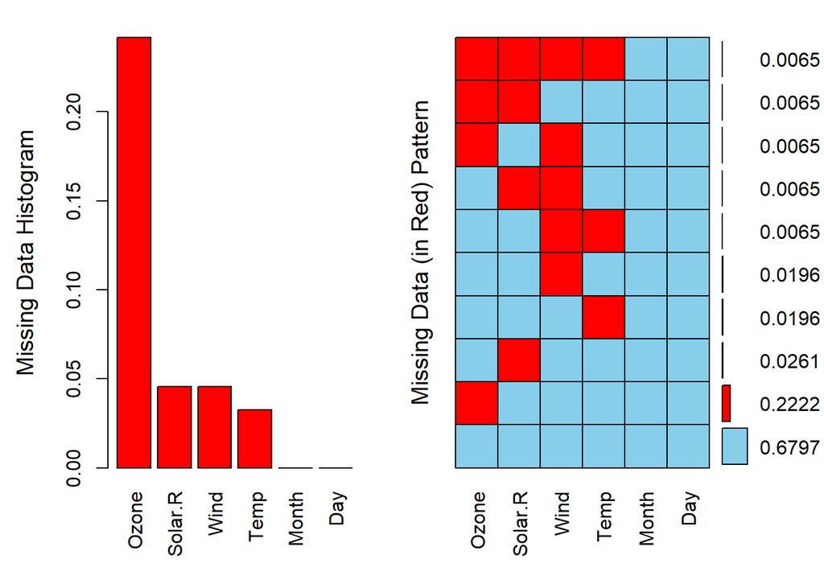

```r
aggr(data, numbers = TRUE, labels = names(data), ylab = c("Missing Data Histogram", "Missing Data (in Red) Pattern"))
```

```r
install.packages("mice")
library(mice)
install.packages("VIM")
library(VIM)
install.packages("ggmice")
library(mice)
data <- airquality
data[4:10, 3] <- NA
data[1:5, 4] <- NA
set.seed(500)  # Set a seed for reproducibility
tempDataImpute <- data  # Create a copy of your dataset
imputedData <- mice(tempDataImpute, method = 'pmm')
```

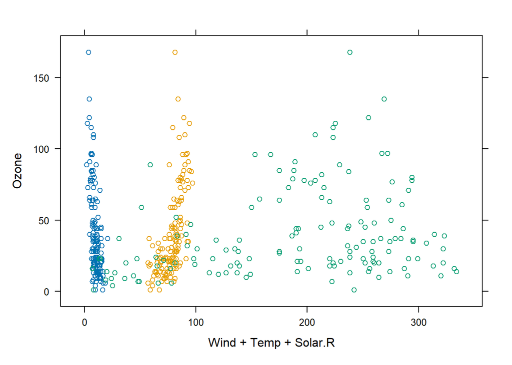

```r
imputedData <- complete(imputedData)

# Create a scatter plot with observed and imputed data points
xyplot(data=imputedData, Ozone ~ Wind+Temp+Solar.R)
```

Activity 4k. The mice function in R is part of the MICE (Multiple Imputation by Chained Equations) package, which is used for imputing missing data. The MICE package provides a flexible framework for imputing missing values in a dataset using a range of imputation methods. The function is used for multiple imputation of missing data. It assumes the Missing At Random (MAR) assumption. The MAR assumption means that the missingness can depend on observed variables but not on unobserved variables after taking into account the observed variables. The MICE algorithm does not assume that the missing data is Missing Completely At Random (MCAR), where the missingness is completely random and unrelated to any observed or unobserved variables. It also does not assume that the missing data is Missing Not At Random (MNAR), where the missingness is related to unobserved variables. By assuming MAR, the MICE algorithm imputes missing values based on observed data and attempts to create plausible imputations that preserve the relationships between variables. It is a flexible and widely used method for handling missing data in statistical analysis. Regarding the specific assumption made by the “mice” function, the package documentation states the following: “The MICE algorithm assumes that data are missing at random (MAR) conditional on the observed data.” Sources: 1. Radečić, D. (n.d.). Imputation in R: Top 3 Ways for Imputing Missing Data. https://appsilon.com/imputation-in-r/ 2. van Buuren, S., & Groothuis-Oudshoorn, K. (2011). MICE: Multivariate imputation by chained equations in R. Journal of statistical software, 45(3), 1-67.